# Principal Component Analysis

```r
knitr::opts_chunk$set(echo = TRUE)
library(tidymodels)
library(tidyverse)
```

# Background

We are going to again use the `ames` dataset, containing information about home prices in Ames, IA.

```r
data(ames)
ames <- ames %>% mutate(Sale_Price = log10(Sale_Price))
```

# PCA

You’ve already looked at a lot of preprocessing steps for this data. Let’s look at feature extraction by examining only the variables that measure the size of some aspect of the home:

```r
ames_sub <- ames %>%
  select(Sale_Price, matches("(SF$)|(Gr_Liv)"))
```

We might guess that these variables are correlated—larger homes have large basements, or large second floors, etc. Let’s take a look:

```r
library(GGally)
```

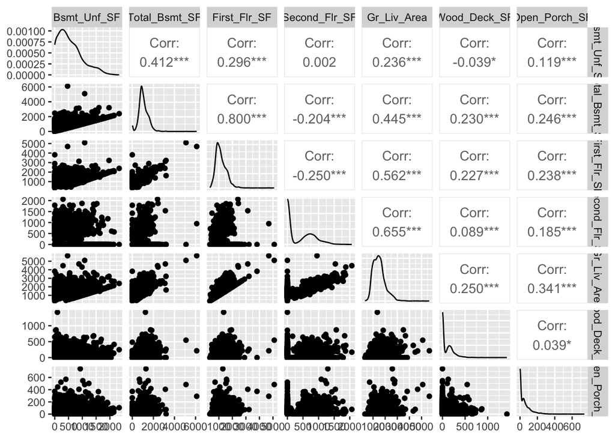

```r
ggpairs(ames_sub %>% select(-Sale_Price))
```

Remember that this plot only shows pair-wise correlations, and not correlations between 3 or more variables.

Let’s take a look at a linear model built with these features.

```r
mod_all <- lm(Sale_Price ~ ., data=ames_sub)
tidy(mod_all)
```

```
## # A tibble: 8 × 5
##   term            estimate  std.error statistic  p.value
##   <chr>              <dbl>      <dbl>     <dbl>    <dbl>
## 1 (Intercept)    4.79      0.00697       688.   0
## 2 Bsmt_Unf_SF   -0.0000355 0.00000502     -7.07 2.00e-12
## 3 Total_Bsmt_SF  0.000169  0.00000795     21.3  6.78e-94
## 4 First_Flr_SF   0.000286  0.0000436       6.57 6.13e-11
## 5 Second_Flr_SF  0.000302  0.0000430       7.03 2.57e-12
## 6 Gr_Liv_Area   -0.000124  0.0000426      -2.90 3.74e- 3
## 7 Wood_Deck_SF   0.000154  0.0000165       9.31 2.47e-20
## 8 Open_Porch_SF  0.000150  0.0000313       4.77 1.91e- 6
```

```r
glance(mod_all)
```

```
## # A tibble: 1 × 12
##   r.squared adj.r.squared sigma statistic p.value    df logLik    AIC    BIC
##       <dbl>         <dbl> <dbl>     <dbl>   <dbl> <dbl>  <dbl>  <dbl>  <dbl>
## 1     0.639         0.638 0.107      738.       0     7  2407. -4797. -4743.
## # ℹ 3 more variables: deviance <dbl>, df.residual <int>, nobs <int>
```

This isn’t a huge number of variables, but there is some correlation, and we might be able to help the model by reducing the number of variables we use.

```r
pca_rec <- recipe(Sale_Price ~ ., data=ames_sub) %>%
  step_normalize(all_numeric_predictors()) %>%
  step_pca(
    all_numeric_predictors(),
    num_comp = 7, # number of principal components to keep, default 5
    #threshold = .75 # can you determine what this does using the help file?
    )
```

Let’s prep and bake this recipe, to see what the output looks like:

```r
pca_prep <- prep(pca_rec)
baked_pca <- bake(
  pca_prep,
  new_data=NULL
)
```

Take a look at `baked_pca`. What do you see?

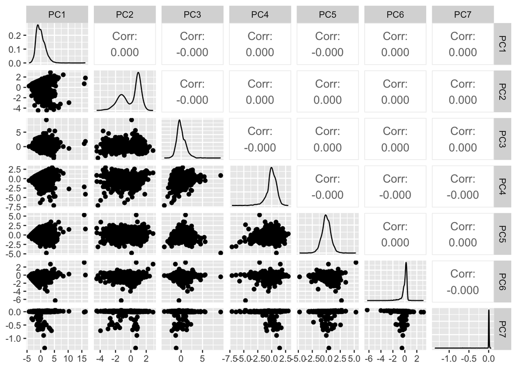

```r
ggpairs(baked_pca %>% select(-Sale_Price))
```

The prepped recipe has all the information about how to perform the linear transform the variables. We’ll take a look at this transformation in these next few code chunks.

Let’s take a look at the following. What is in the `value` column?

```r
tidied_pca <- tidy(pca_prep, 2) #information about step 2: PCA
tidied_pca
```

```
## # A tibble: 49 × 4
##    terms          value component id
##    <chr>          <dbl> <chr>     <chr>
##  1 Bsmt_Unf_SF   0.303  PC1       pca_3TYa8
##  2 Total_Bsmt_SF 0.515  PC1       pca_3TYa8
##  3 First_Flr_SF  0.521  PC1       pca_3TYa8
##  4 Second_Flr_SF 0.0925 PC1       pca_3TYa8
##  5 Gr_Liv_Area   0.483  PC1       pca_3TYa8
##  6 Wood_Deck_SF  0.219  PC1       pca_3TYa8
##  7 Open_Porch_SF 0.286  PC1       pca_3TYa8
##  8 Bsmt_Unf_SF   0.147  PC2       pca_3TYa8
##  9 Total_Bsmt_SF 0.308  PC2       pca_3TYa8
## 10 First_Flr_SF  0.286  PC2       pca_3TYa8
## # ℹ 39 more rows
```

Now we can get a sense for which variables have the most influence on the principle components 1-5:

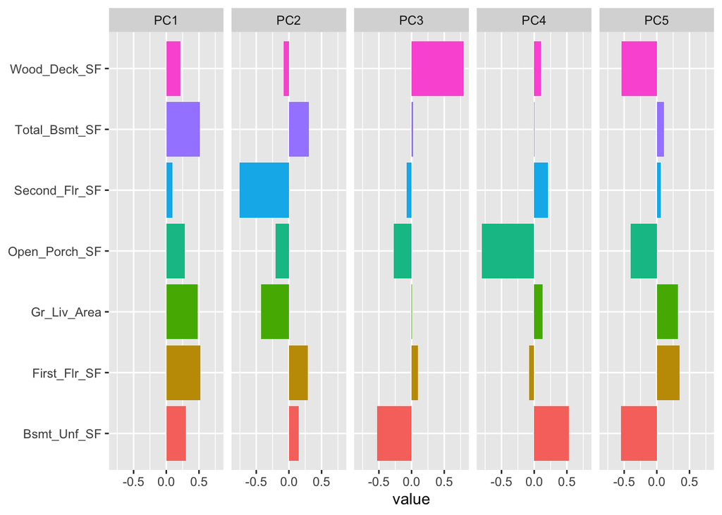

```r
tidied_pca %>%
  filter(component %in% paste0("PC", 1:5)) %>%
  mutate(component = fct_inorder(component)) %>%
  ggplot(aes(value, terms, fill = terms)) +
  geom_col(show.legend = FALSE) +
  facet_wrap(~component, nrow = 1) +
  labs(y = NULL)
```

Here is another way to think about this:

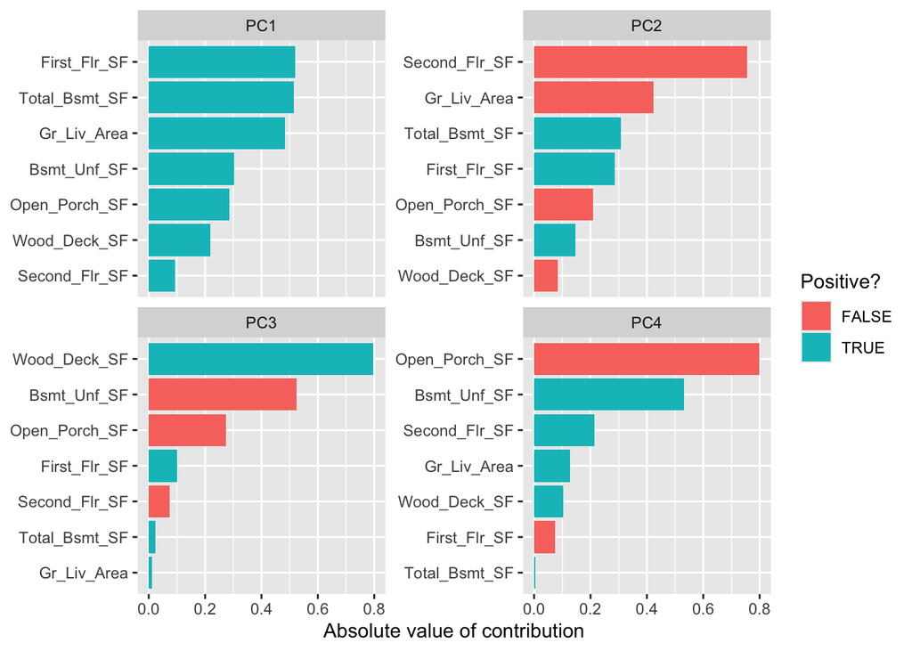

```r
library(tidytext)

tidied_pca %>%
  filter(component %in% paste0("PC", 1:4)) %>%
  group_by(component) %>%
  top_n(8, abs(value)) %>%
  ungroup() %>%
  mutate(terms = reorder_within(terms, abs(value), component)) %>%
  ggplot(aes(abs(value), terms, fill = value > 0)) +
  geom_col() +
  facet_wrap(~component, scales = "free_y") +
  scale_y_reordered() +
  labs(
    x = "Absolute value of contribution",
    y = NULL, fill = "Positive?"
  )
```

Inside of my prepped recipe, I also have a column which tells me how much variation is captured by each principal component:

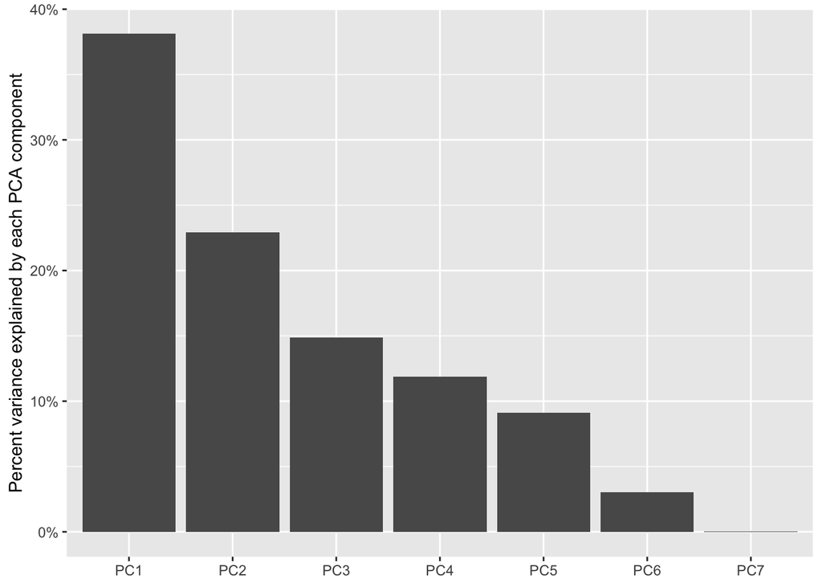

```r
# pull out second step: PCA, then take the std dev of the residuals
sdev <- pca_prep$steps[[2]]$res$sdev
percent_variation <- sdev^2 / sum(sdev^2)

tibble(
  component = unique(tidied_pca$component),
  percent_var = percent_variation
) %>%
  mutate(component = fct_inorder(component)) %>%
  ggplot(aes(component, percent_var)) +
  geom_col() +
  scale_y_continuous(labels = scales::percent_format()) +
  labs(x = NULL, y = "Percent variance explained by each PCA component")
```

What do you see from this plot? How many principle components do we really need to accurately capture the information in this data?

Another way to get this information is a scree plot, which you will make on your homework.

```r
model_pca <- lm(Sale_Price ~ PC1 + PC2 + PC3 + PC4 + PC5, data=baked_pca)
tidy(model_pca)
```

```
## # A tibble: 6 × 5
##   term        estimate std.error statistic  p.value
##   <chr>          <dbl>     <dbl>     <dbl>    <dbl>
## 1 (Intercept)  5.22      0.00202   2588.   0
## 2 PC1          0.0810    0.00124     65.6  0
## 3 PC2         -0.0224    0.00159    -14.1  1.83e-43
## 4 PC3          0.0235    0.00198     11.9  6.96e-32
## 5 PC4         -0.00272   0.00221     -1.23 2.18e- 1
## 6 PC5          0.0291    0.00253     11.5  4.98e-30
```

```r
glance(model_pca)
```

```
## # A tibble: 1 × 12
##   r.squared adj.r.squared sigma statistic p.value    df logLik    AIC    BIC
##       <dbl>         <dbl> <dbl>     <dbl>   <dbl> <dbl>  <dbl>  <dbl>  <dbl>
## 1     0.620         0.620 0.109      955.       0     5  2335. -4656. -4614.
## # ℹ 3 more variables: deviance <dbl>, df.residual <int>, nobs <int>
```

This is an unsupervised technique, meaning we do not take into account the objective: in this case, predicting the value of `Sale_Price`. Since we are interested in supervised prediction, we should try to use that information as we learn important directions. This is a process called Partial Least Squares.